# Datenvisualisierung 3

- Gesamten Code zeigen
- Gesamten Code verbergen
- Quellcode anzeigen

Darstellung der zusammenfassenden Statistik

Autor:in

Zugehörigkeit

Daniela Palleschi

Humboldt-Universität zu Berlin

Veröffentlichungsdatum

18. Dezember 2023

# Learning objectives

Today we will learn to…

- create and interpret boxplots
- visualize mean values and standard deviations

# Ressourcen

- [Abschnitt 2.5 (Visualisierung von Beziehungen)](https://r4ds.hadley.nz/data-visualize#visualizing-relationships) in Wickham et al. (2023)
- [Kapitel 4 (Darstellung von zusammenfassenden Statistiken)](https://psyteachr.github.io/introdataviz/representing-summary-statistics.html) in Nordmann et al. (2022)
- Abschnitte 3.5-3.9 in Winter (2019)

# Einrichten

## Pakete

```r
pacman::p_load(tidyverse,
               here,
               janitor,
               ggthemes,
               patchwork)
```

## Daten

```r
df_eng <- read_csv(
  here(
    "daten",
    "languageR_english.csv"
  )
) |>
  clean_names() |>
  rename(
    rt_lexdec = r_tlexdec,
    rt_naming = r_tnaming
  )
```

# 1 Rückblick: Visualisierung von Verteilungen

- Betrachten Sie jede Abbildung in Abbildung 1
  - Wie viele Variablen werden in jeder Abbildung dargestellt?
  - welche *Typen* von Variablen sind es?
  - Welche zusammenfassende(n) Statistik(en) wird/werden in jedem Diagramm dargestellt?

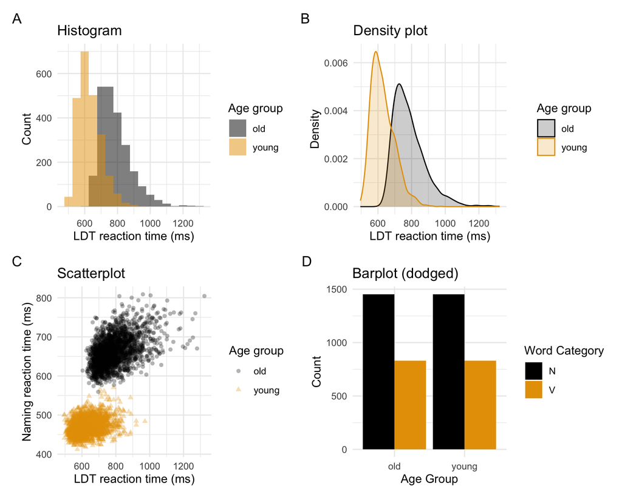

Abbildung 1: Different plots types

# 2 Darstellung von zusammenfassenden Statistiken

- Modus und Bereich werden in Histogrammen und Dichteplots visualisiert
- die Anzahl der Beobachtungen wird in Balkendiagrammen visualisiert

## 2.1 Boxplot

- auch bekannt als Box-and-Whisker-Plots, enthalten
  - eine Box
  - eine Linie in der Mitte der Box
  - Linien, die an beiden Enden der Box herausragen (die ‘Whisker’)
  - manchmal Punkte

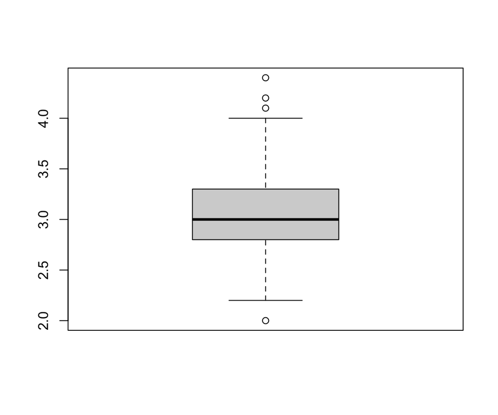

- Betrachten Sie Abbildung 2
  - identifiziere jeden dieser 4 Aspekte des Plots
  - können Sie erraten, was jeder dieser Aspekte darstellen könnte und wie Sie die Darstellung interpretieren sollten?

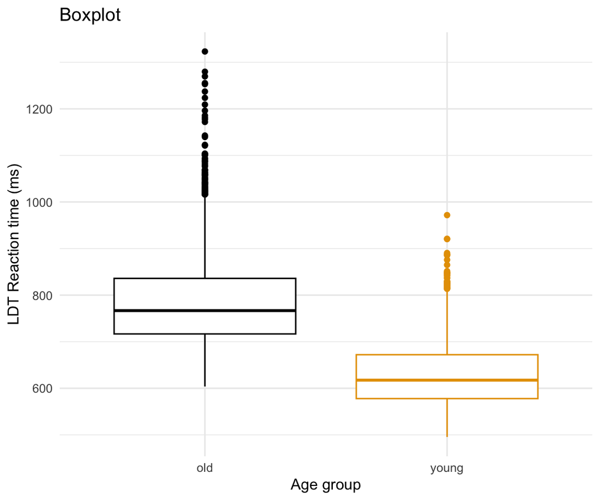

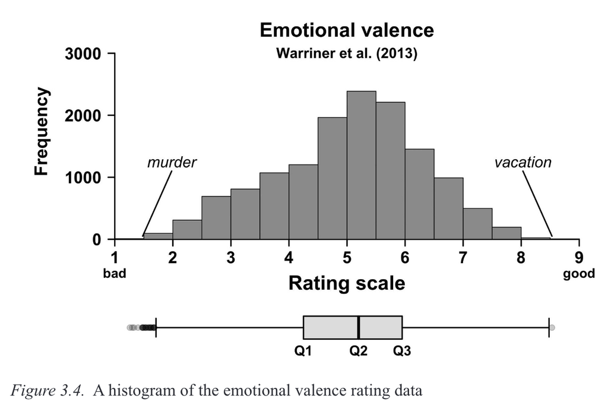

Image source: Winter (2019) (all rights reserved)

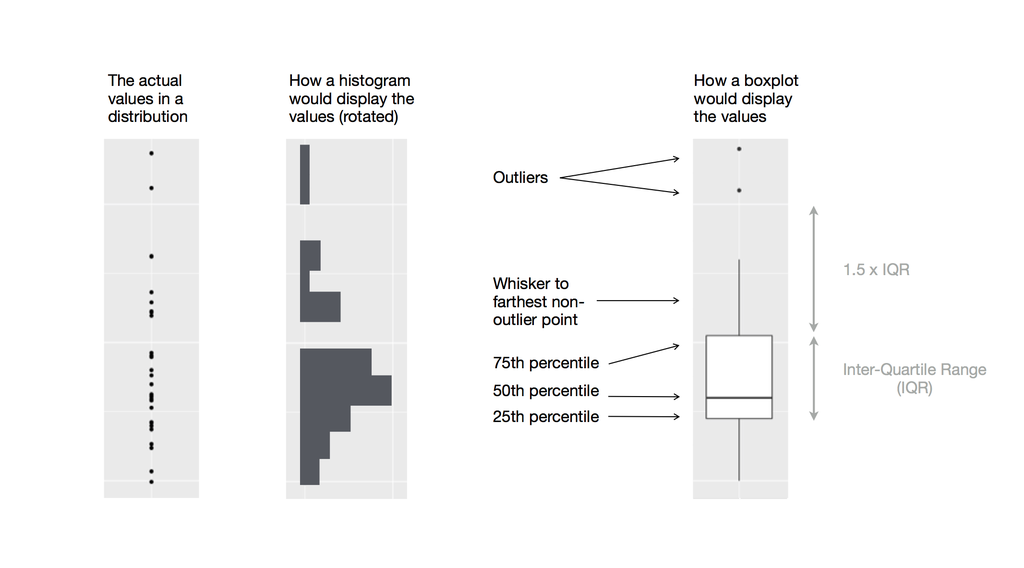

Image source: Wickham et al. (2023) (all rights reserved)

### 2.1.1 `geom_boxplot()`

- Die Funktion `geom_boxplot()` von `ggplot2` erzeugt Boxplots
  - sie benötigt eine numerische Variable als `x` oder `y` Achse (Abbildung 3)

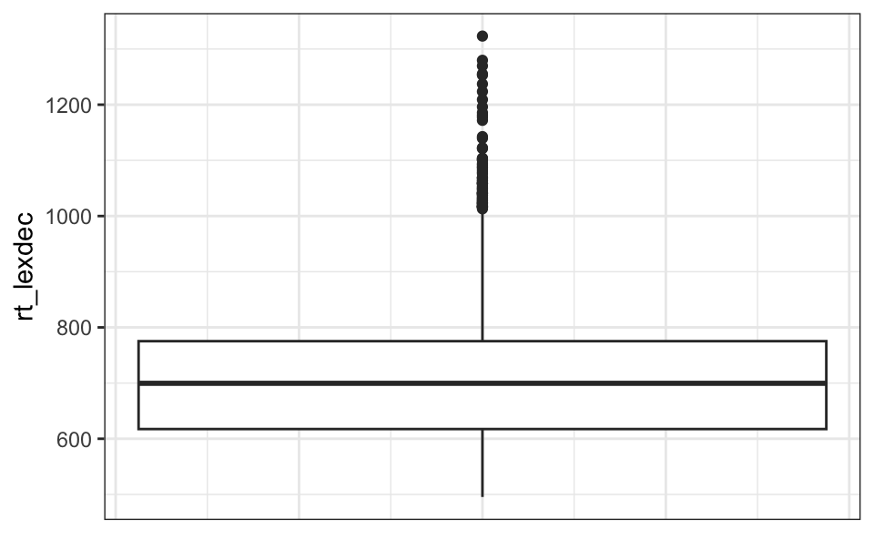

Abbildung 3: A boxplot for all observations of a continuous variable

```r
df_eng |>
  ggplot(aes(y = rt_lexdec)) +
  geom_boxplot()
```

- für Boxplots verschiedener Gruppen: eine kategorische Variable entlang der anderen Achse (Abbildung 4)

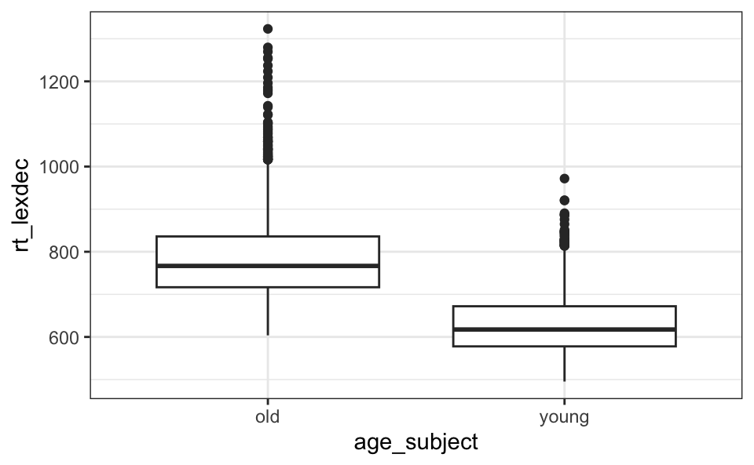

Abbildung 4: A boxplot for two groups

```r
df_eng |>
  ggplot(aes(x = age_subject, y = rt_lexdec)) +
  geom_boxplot() +
  theme_bw()
```

### 2.1.2 Gruppierter Boxplot

- Wir können gruppierte Boxplots erstellen, um mehr Variablen zu visualisieren
  - einfach eine neue Variable mit `colour` oder `fill` ästhetisch zuordnen

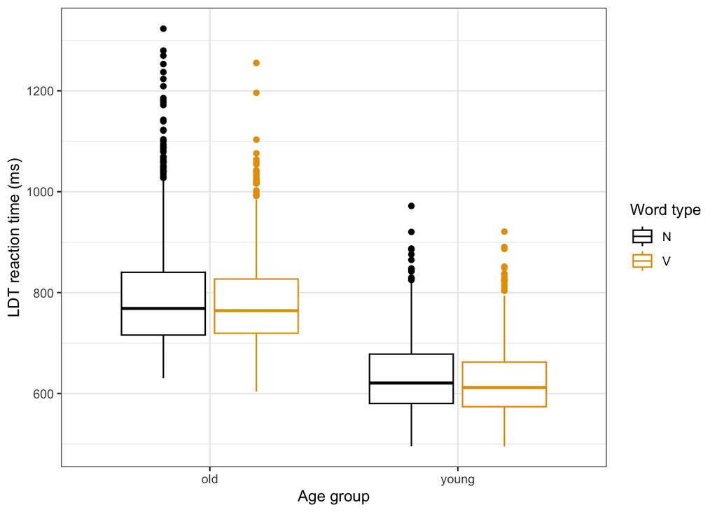

A grouped boxplot

```r
df_eng |>
  ggplot(aes(x = age_subject, y = rt_lexdec, colour = word_category)) +
  geom_boxplot() +
  labs(
    x = "Age group",
    y = "LDT reaction time (ms)",
    color = "Word type"
  ) +
  scale_colour_colorblind() +
  theme_bw()
```

# 3 Visualisierung des Mittelwerts

- In der Regel wollen wir auch den Mittelwert mit der Standardabweichung darstellen.
  - Wie können wir das tun?

## 3.1 Fehlerbalkenplots

- Diese Diagramme bestehen aus 2 Teilen:
  - der Mittelwert, visualisiert mit `geom_point()`
  - ein Maß für die Streuung, visualisiert mit “geom_errorbar()”.
- für diesen Kurs werden wir die Standardabweichung verwenden
- Abbildung 5 ist das, was wir heute erzeugen werden

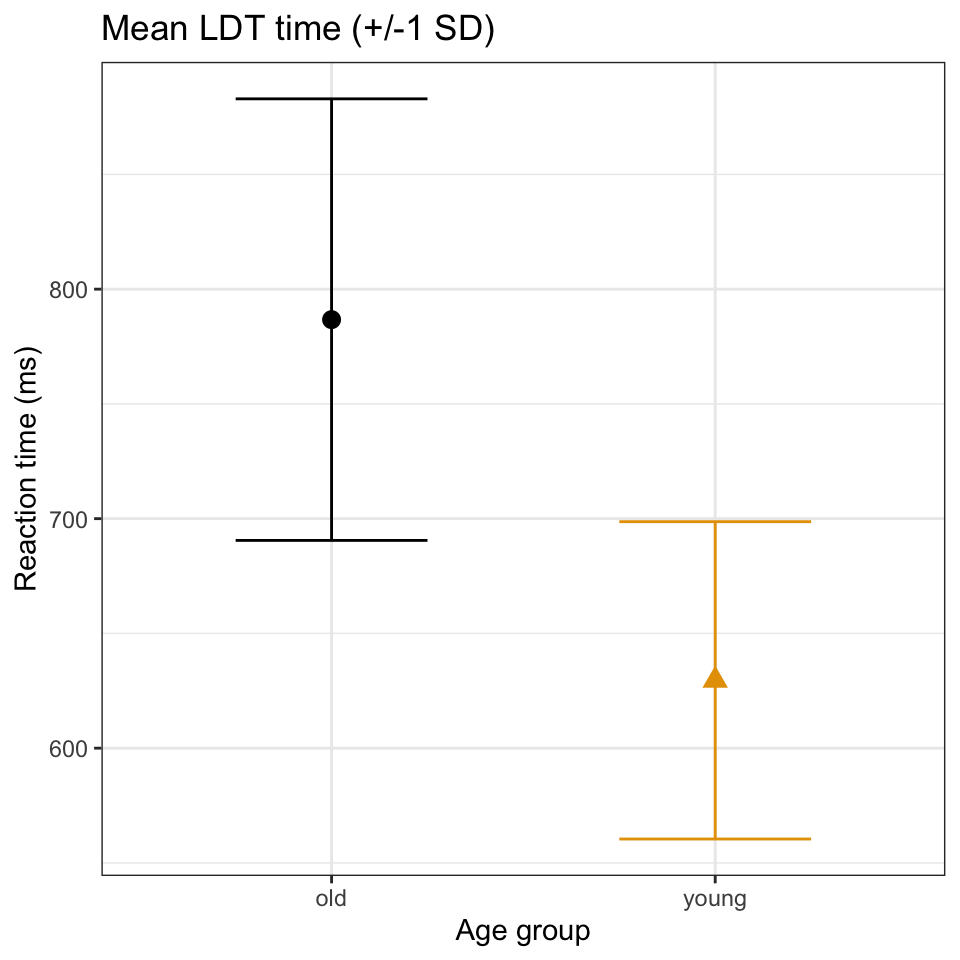

### 3.1.1 Berechnung der zusammenfassenden Statistik

- müssen wir zunächst den Mittelwert und die Standardabweichung berechnen
  - gruppiert nach den Variablen, die wir visualisieren wollen
- Wie kann man den Mittelwert und die Standardabweichung von `rt_lexdec` nach `age_subject` berechnen?

**Click here to see how**

```r
sum_eng <- df_eng |>
  summarise(mean = mean(rt_lexdec),
            sd = sd(rt_lexdec),
            N = n(),
            .by = age_subject) |>
  arrange(age_subject, age_subject)
```

- Diese Zusammenfassung können wir dann in `ggplot()` mit den entsprechenden ästhetischen Zuordnungen und Geomen einfügen

### 3.1.2 Plotting mean

- Zunächst werden die Mittelwerte mit “geom_point()” dargestellt.

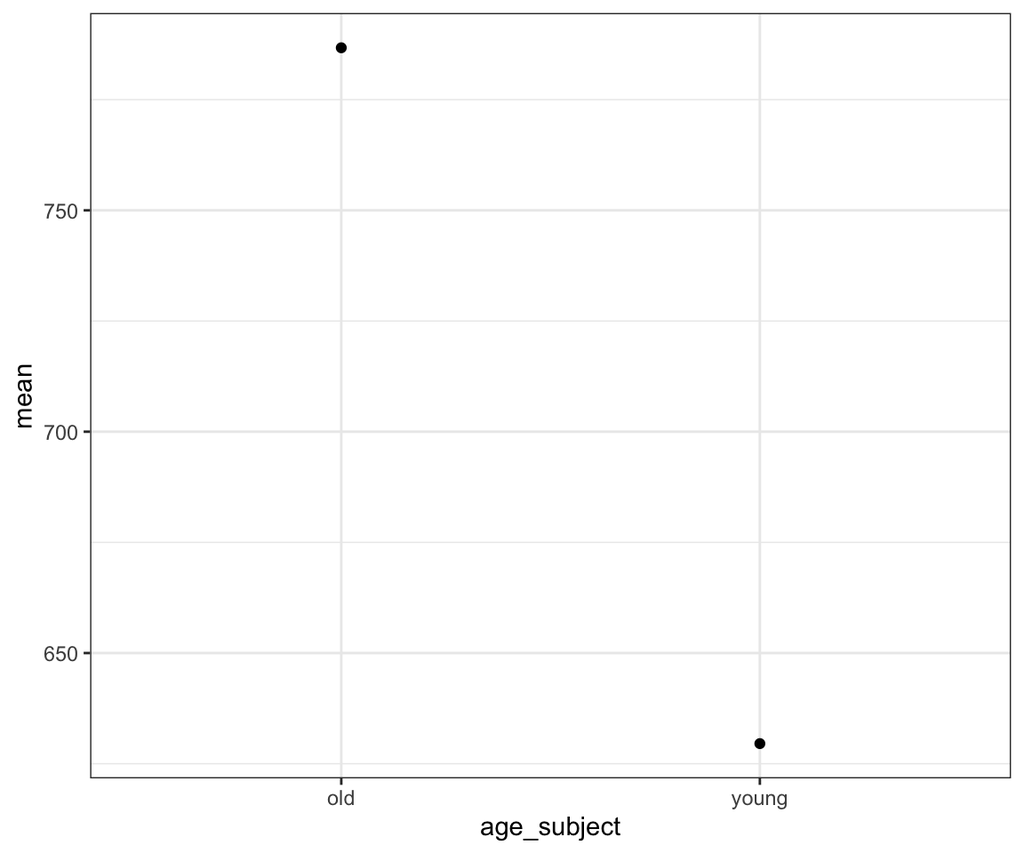

```r
sum_eng |>
  ggplot() +
  aes(x = age_subject, y = mean) +
  geom_point()
```

### 3.1.3 Hinzufügen von Fehlerbalken

- Fügen wir nun unsere Fehlerbalken hinzu, die 1 Standardabweichung über und unter dem Mittelwert darstellen
- wir tun dies mit `geom_errorbar()`
  - nimmt `ymin` und `ymax` als Argumente
  - In unserem Fall sind dies `mean-/+sd`.

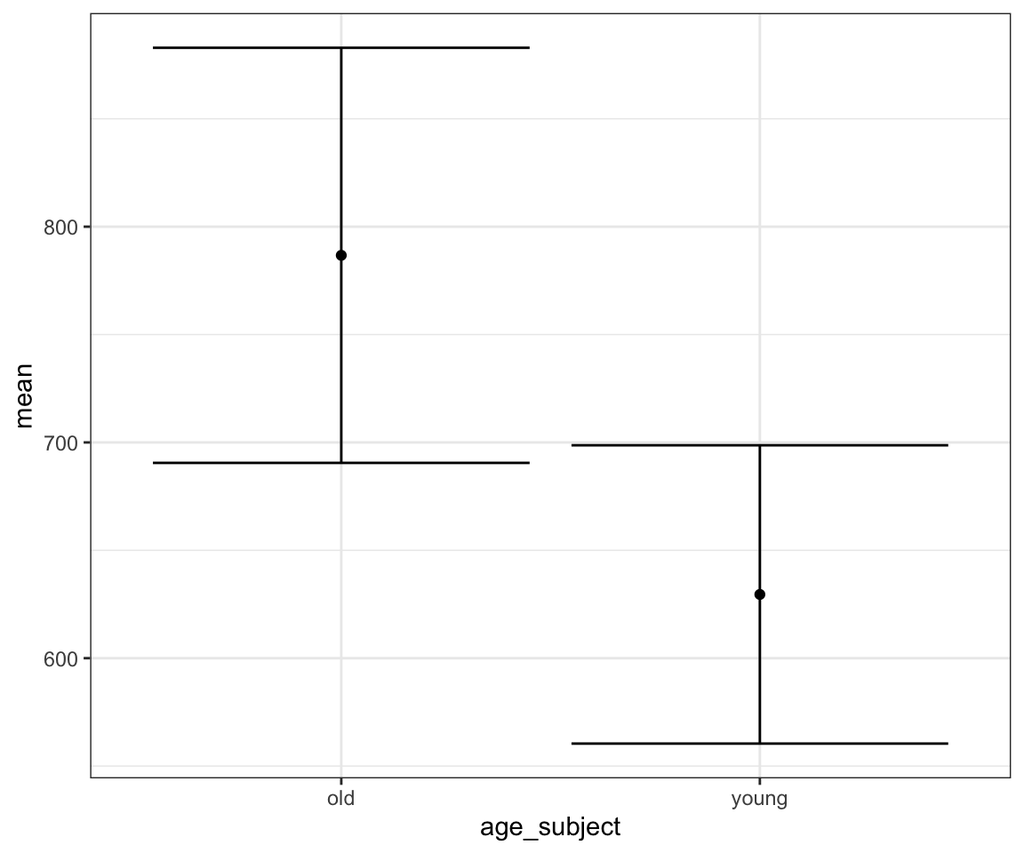

```r
sum_eng |>
  ggplot() +
  aes(x = age_subject, y = mean) +
  geom_point() +
  geom_errorbar(aes(ymin = mean-sd,
                    ymax = mean+sd))
```

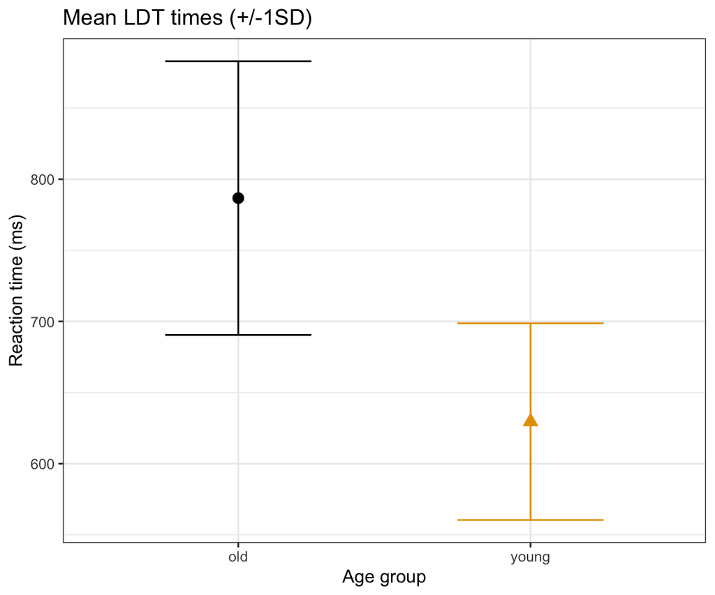

```r
sum_eng |>
  ggplot(aes(x = age_subject, y = mean, colour = age_subject, shape = age_subject)) +
  # geom_point(data = df_eng, alpha = .4, position = position_jitterdodge(.5), aes(x = age_subject, y = rt_lexdec)) +
  geom_point(size = 3) +
  geom_errorbar(width = .5, aes(ymin=mean-sd, ymax=mean+sd)) +
  labs(title = "Mean LDT times (+/-1SD)",
    x = "Age group",
    y = "Reaction time (ms)",
    color = "Age group"
  ) +
  scale_color_colorblind() +
  theme_bw() +
  theme(
    legend.position = "none"
  )
```

# 4 Barplot von Mittelwerten: Bleiben Sie weg!

- Sie werden sehr oft Balkendiagramme von Mittelwerten sehen
  - aber es gibt viele Gründe, warum dies eine schlechte Idee ist!!
- Der Balkenplot hat ein schlechtes Daten-Tinten-Verhältnis, d.h. die Menge der Datentinte geteilt durch die Gesamttinte, die zur Erstellung der Grafik benötigt wird
  - Was ist, wenn es nur sehr wenige oder gar keine Beobachtungen in der Nähe von Null gibt? Wir verbrauchen eine Menge Tinte, wo es keine Beobachtungen gibt!
  - Außerdem deckt der Balken nur den Bereich ab, in dem die untere *Hälfte* der Beobachtungen liegt; ebenso viele Beobachtungen liegen über dem Mittelwert!
- Fehlerbalken allein sind keine Lösung: auch hier wird eine Menge Information verborgen
  - ein guter Grund, die Rohdatenpunkte *immer* zu visualisieren, unabhängig davon, welche zusammenfassende Darstellung Sie erstellen

# Learning objects 🏁

In this section we learned how to…

- produce and interpret boxplots ✅
- produce and interpret errorbar plots ✅

## Hausaufgabe

### Errorbar plot

2. Versuchen Sie, Abbildung 6 zu reproduzieren. Hinweis: Sie werden die Variable `rt_naming` aus `df_eng` verwenden.

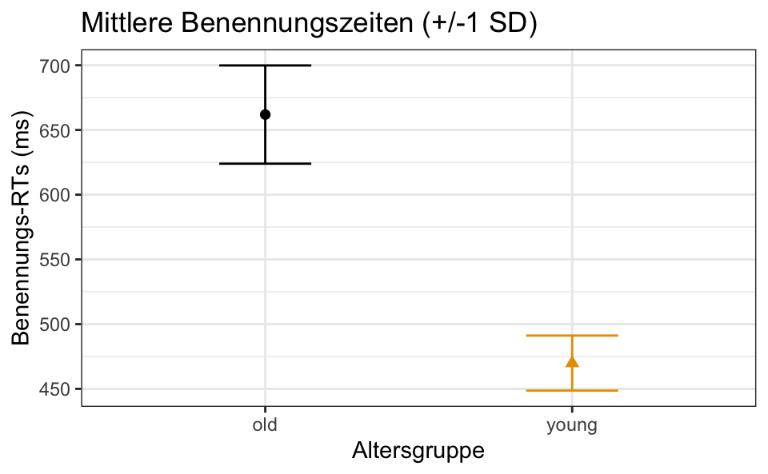

Abbildung 6: Plot to be reproduced

### Patchwork

3. Verwenden Sie das Paket `patchwork`, um Ihren Boxplot und Ihre Fehlerbalkenplots nebeneinander darzustellen. Es sollte ungefähr so aussehen wie Abbildung 7. Hinweis: Wenn Sie die “tag-level” (“A” und “B”) zu den Plots hinzufügen möchten, müssen Sie `+ plot_annotation(tag_level = "A")` aus `patchwork` hinzufügen.

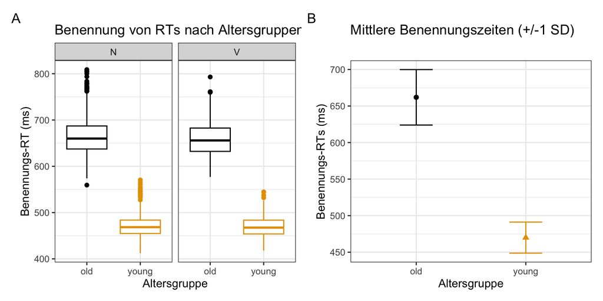

Abbildung 7: Combined plots with `patchwork`

# Session Info

Hergestellt mit R version 4.3.0 (2023-04-21) (Already Tomorrow) und RStudioversion 2023.9.0.463 (Desert Sunflower).

# Literaturverzeichnis

Nordmann, E., McAleer, P., Toivo, W., Paterson, H., & DeBruine, L. M. (2022). Data Visualization Using R for Researchers Who Do Not Use R. *Advances in Methods and Practices in Psychological Science*, *5*(2), 251524592210746. https://doi.org/10.1177/25152459221074654

Wickham, H., Çetinkaya-Rundel, M., & Grolemund, G. (2023). *R for Data Science* (2. Aufl.).

Winter, B. (2019). Statistics for Linguists: An Introduction Using R. In *Statistics for Linguists: An Introduction Using R*. Routledge. https://doi.org/10.4324/9781315165547